# Borderless

Rosie Zheng

10-2-2021

```r
library(spotifyr)
library(tidyverse)
library(dplyr)
library(hrbrthemes)
library(viridis)
```

```r
library(ggplot2)
```

### Used Playlists

```r
borderless <- get_playlist_audio_features("", "37i9dQZF1DWZJmo7mlltU6")
pop <- get_playlist_audio_features("", "37i9dQZF1DXcBWIGoYBM5M")
hiphop <- get_playlist_audio_features("", "37i9dQZF1DX0XUsuxWHRQd")
dance <- get_playlist_audio_features("", "37i9dQZF1DXaXB8fQg7xif")
rock <- get_playlist_audio_features("", "37i9dQZF1DWXRqgorJj26U")
indie <- get_playlist_audio_features("", "37i9dQZF1DX2Nc3B70tvx0")
```

```r
playlists_portfolio <-
  bind_rows(
    borderless %>% mutate(category = "Borderless"),
    pop %>% mutate(category = "Pop"),
    hiphop %>% mutate(category = "Hip-Hop"),
    dance %>% mutate(category = "Dance/Electronic"),
    rock %>% mutate(category = "Rock"),
    indie %>% mutate(category = "Indie")
  )
```

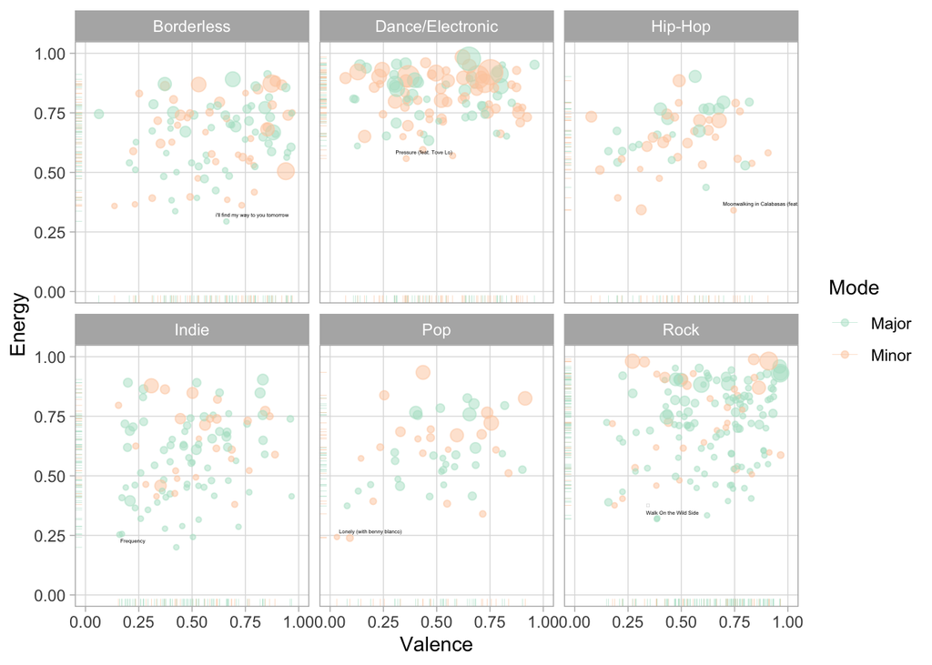

```r
playlists_portfolio %>%
  mutate(
    mode = ifelse(mode == 0, "Minor", "Major")
  ) %>%
  ggplot(
    aes(
      x = valence,
      y = energy,
      size = loudness,
      color = mode
    )
  ) +
  geom_point(alpha=0.5) +
  geom_rug(size = 0.1) +
  geom_text(
    aes(
      x = valence,
      y = energy,
      label = label
    ),
    data =
      tibble(
        label = c("i'll find my way to you tomorrow", "Lonely (with benny blanco)", "
Walk On the Wild Side", "Frequency", "Pressure (feat. Tove Lo)", "Moonwalking in Calabasas (feat. Blueface) - Remix"),
        category = c("Borderless", "Pop", "Rock", "Indie", "Dance/Electronic", "Hip-Hop"),
        valence = c(0.6610, 0.0927, 0.385, 0.2140, 0.3570, 0.7450),
        energy = c(0.294, 0.239, 0.318, 0.200, 0.558, 0.341)
      ),
    colour = "black",
    size = 1,
    hjust = "left",
    vjust = "bottom",
    nudge_x = -0.05,
    nudge_y = 0.02
  ) +
  facet_wrap(~category) +
  scale_x_continuous(
    limits = c(0, 1),
    breaks = c(0, 0.25, 0.5,0.75, 1),
    minor_breaks = NULL
  ) +
  scale_y_continuous(
    limits = c(0, 1),
    breaks = c(0, 0.25, 0.5, 0.75, 1),
    minor_breaks = NULL
  ) +
  scale_colour_brewer(
    type = "qual",
    palette = "Pastel2"
  ) +
  scale_size_continuous(
    trans = "exp",
    guide = "none"
  ) +
  theme_light() +
  labs(
    x = "Valence",
    y = "Energy",
    colour = "Mode"
  )
```

Regarding these graphs, the Borderless playlist is widely distributed over valence and has energy levels of 0.25 and up. It seems that the higher the energy and valence, the louder the music. There are slighly more songs with major modalities than with minor ones. When comparing the Borderless playlist with the other genres, we observe that energy levels are similar to Hip-Hop, Pop, and Indie, valence levels are similar to Rock, loudness levels are similar to Pop and Hip-Hop, and mode is similar to Pop.

```r
# Sample size
sample_size_portfolio = playlists_portfolio %>% group_by(playlist_name) %>% summarize(num=n())
```

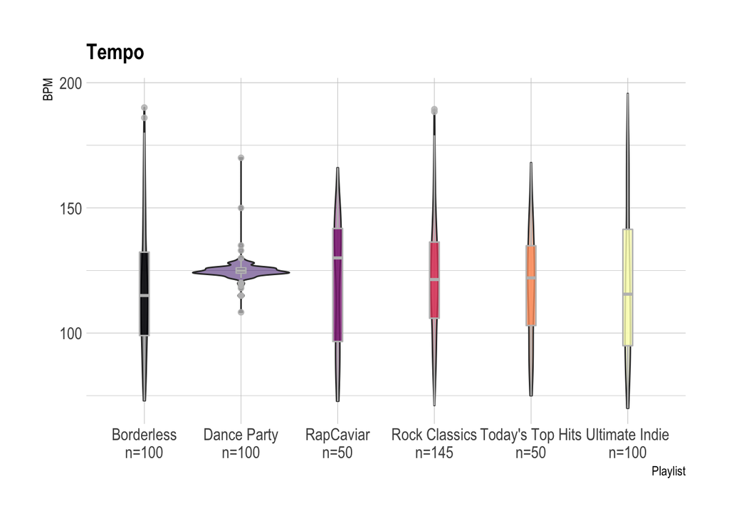

```r
# Plot
playlists_portfolio %>%
  left_join(sample_size_portfolio) %>%
  mutate(myaxis = paste0(playlist_name, "\n", "n=", num)) %>%
  ggplot( aes(x=myaxis, y=tempo, fill=playlist_name)) +
    geom_violin(width=1, alpha=0.5) +
    geom_boxplot(width=0.1, color="grey", alpha=0.8) +
    scale_fill_viridis(discrete=TRUE, guide=FALSE, option="A") +
    theme_ipsum() +
    theme(
      legend.position="none",
      plot.title = element_text(size=15)
    ) +
    ggtitle("Tempo") +
    xlab("Playlist") +
  ylab("BPM")
```

The mean tempo for the Borderless playlist lays around 120 BPM. This mean comes closest to the Indie playlist and is mostly different from the Dance playlist. Furthermore, we observe that the distribution for tempo is wide-spread for the Borderless playlist and is similar to the distributions of the Rock, Pop, and Indie playlist.

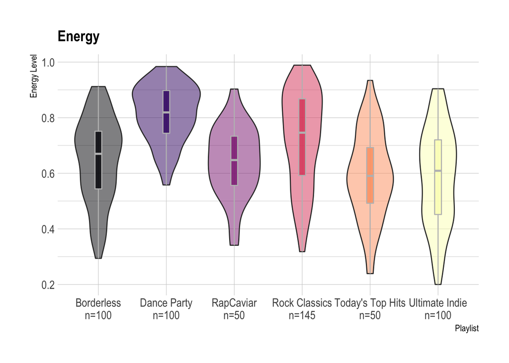

```r
# Plot
playlists_portfolio %>%
  left_join(sample_size_portfolio) %>%
  mutate(myaxis = paste0(playlist_name, "\n", "n=", num)) %>%
  ggplot( aes(x=myaxis, y=energy, fill=playlist_name)) +
    geom_violin(width=1, alpha=0.5) +
    geom_boxplot(width=0.1, color="grey", alpha=0.8) +
    scale_fill_viridis(discrete=TRUE, guide=FALSE, option="A") +
    theme_ipsum() +
    theme(
      legend.position="none",
      plot.title = element_text(size=15)
    ) +
    ggtitle("Energy") +
    xlab("Playlist") +
  ylab("Energy Level")
```

In the first graph, we observed that energy levels for Borderless were similar to Hip-Hop, Pop, and Indie. Here we can observe that the violin shape is mostly the samefor Pop and indie. Rap, however, shares the same boxplot.

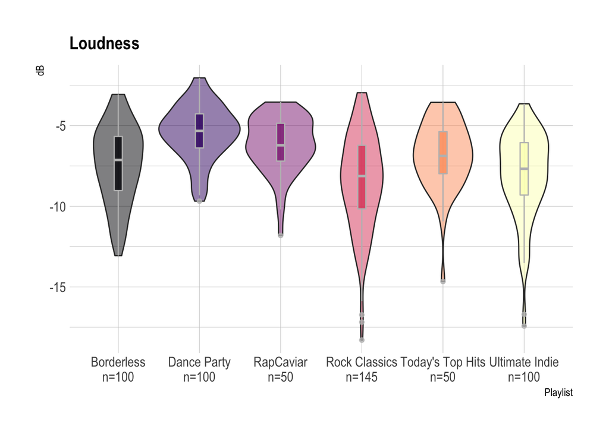

```r
# Plot
playlists_portfolio %>%
  left_join(sample_size_portfolio) %>%
  mutate(myaxis = paste0(playlist_name, "\n", "n=", num)) %>%
  ggplot( aes(x=myaxis, y=loudness, fill=playlist_name)) +
    geom_violin(width=1, alpha=0.5) +
    geom_boxplot(width=0.1, color="grey", alpha=0.8) +
    scale_fill_viridis(discrete=TRUE, guide=FALSE, option="A") +
    theme_ipsum() +
    theme(
      legend.position="none",
      plot.title = element_text(size=15)
    ) +
    ggtitle("Loudness") +
    xlab("Playlist") +
  ylab("dB")
```

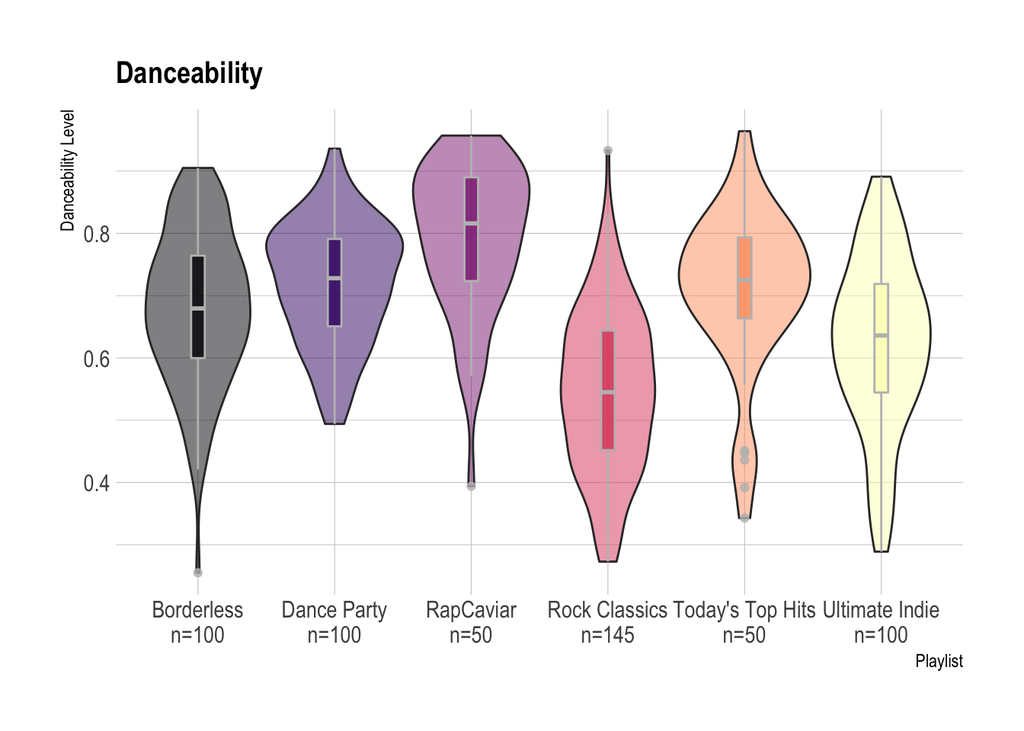

```r
# Plot
playlists_portfolio %>%
  left_join(sample_size_portfolio) %>%
  mutate(myaxis = paste0(playlist_name, "\n", "n=", num)) %>%
  ggplot( aes(x=myaxis, y=danceability, fill=playlist_name)) +
    geom_violin(width=1, alpha=0.5) +
    geom_boxplot(width=0.1, color="grey", alpha=0.8) +
    scale_fill_viridis(discrete=TRUE, guide=FALSE, option="A") +
    theme_ipsum() +
    theme(
      legend.position="none",
      plot.title = element_text(size=15)
    ) +
    ggtitle("Danceability") +
    xlab("Playlist") +
  ylab("Danceability Level")
```

Danceability for Borderless is mostly similar to Indie.

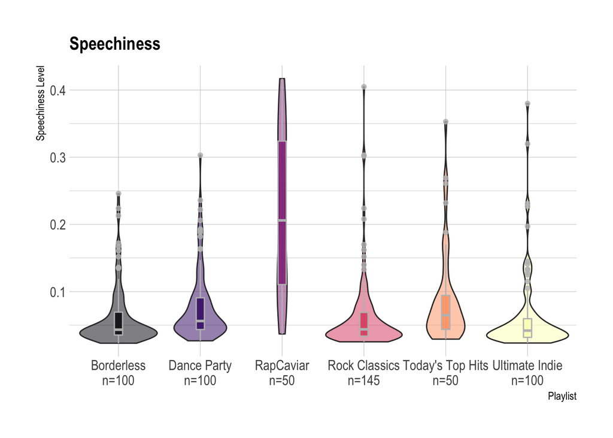

```r
# Plot
playlists_portfolio %>%
  left_join(sample_size_portfolio) %>%
  mutate(myaxis = paste0(playlist_name, "\n", "n=", num)) %>%
  ggplot( aes(x=myaxis, y=speechiness, fill=playlist_name)) +
    geom_violin(width=1, alpha=0.5) +
    geom_boxplot(width=0.1, color="grey", alpha=0.8) +
    scale_fill_viridis(discrete=TRUE, guide=FALSE, option="A") +
    theme_ipsum() +
    theme(
      legend.position="none",
      plot.title = element_text(size=15)
    ) +
    ggtitle("Speechiness") +
    xlab("Playlist") +
  ylab("Speechiness Level")
```

Speechiness is low for every genre except Hip-Hop which is logical. Borderless comes closest to Rock and Indie.

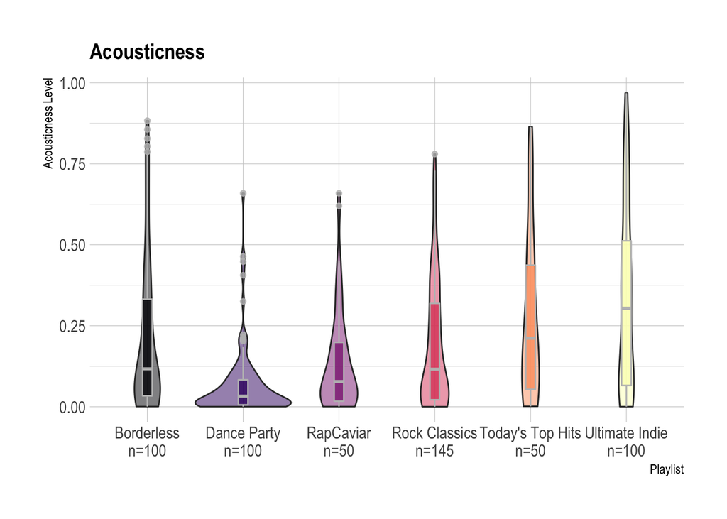

```r
# Plot
playlists_portfolio %>%
  left_join(sample_size_portfolio) %>%
  mutate(myaxis = paste0(playlist_name, "\n", "n=", num)) %>%
  ggplot( aes(x=myaxis, y=acousticness, fill=playlist_name)) +
    geom_violin(width=1, alpha=0.5) +
    geom_boxplot(width=0.1, color="grey", alpha=0.8) +
    scale_fill_viridis(discrete=TRUE, guide=FALSE, option="A") +
    theme_ipsum() +
    theme(
      legend.position="none",
      plot.title = element_text(size=15)
    ) +
    ggtitle("Acousticness") +
    xlab("Playlist") +
  ylab("Acousticness Level")
```

The distribution for acousticness is almost the same for Rock. It is completely different from Dance.

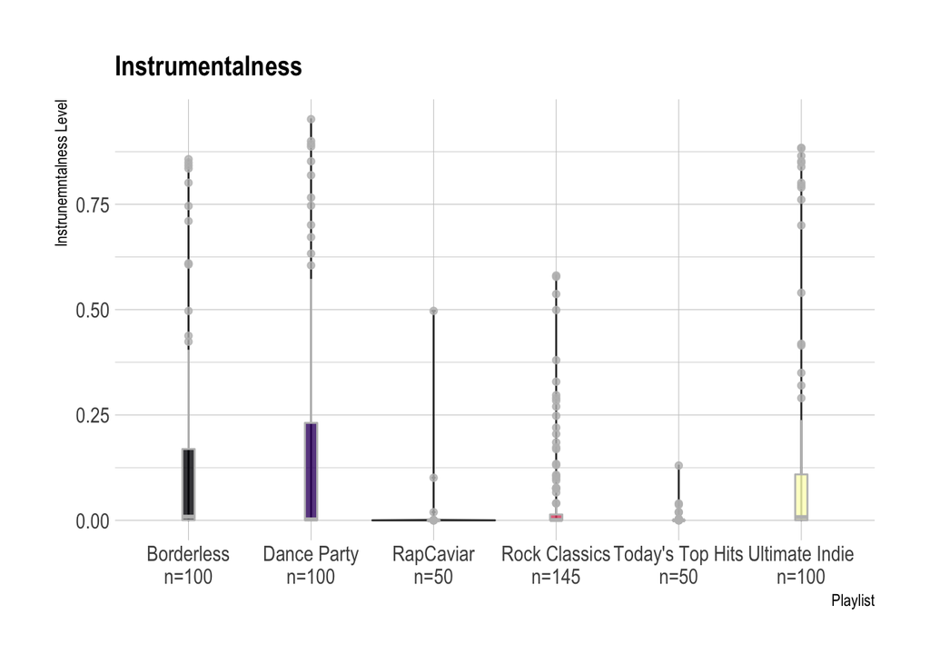

```r
# Plot
playlists_portfolio %>%
  left_join(sample_size_portfolio) %>%
  mutate(myaxis = paste0(playlist_name, "\n", "n=", num)) %>%
  ggplot( aes(x=myaxis, y=instrumentalness, fill=playlist_name)) +
    geom_violin(width=1, alpha=0.5) +
    geom_boxplot(width=0.1, color="grey", alpha=0.8) +
    scale_fill_viridis(discrete=TRUE, guide=FALSE, option="A") +
    theme_ipsum() +
    theme(
      legend.position="none",
      plot.title = element_text(size=15)
    ) +
    ggtitle("Instrumentalness") +
    xlab("Playlist") +
  ylab("Instrunemntalness Level")
```

It seems that instrumentalness cannot be visualized very well with a violin plot.

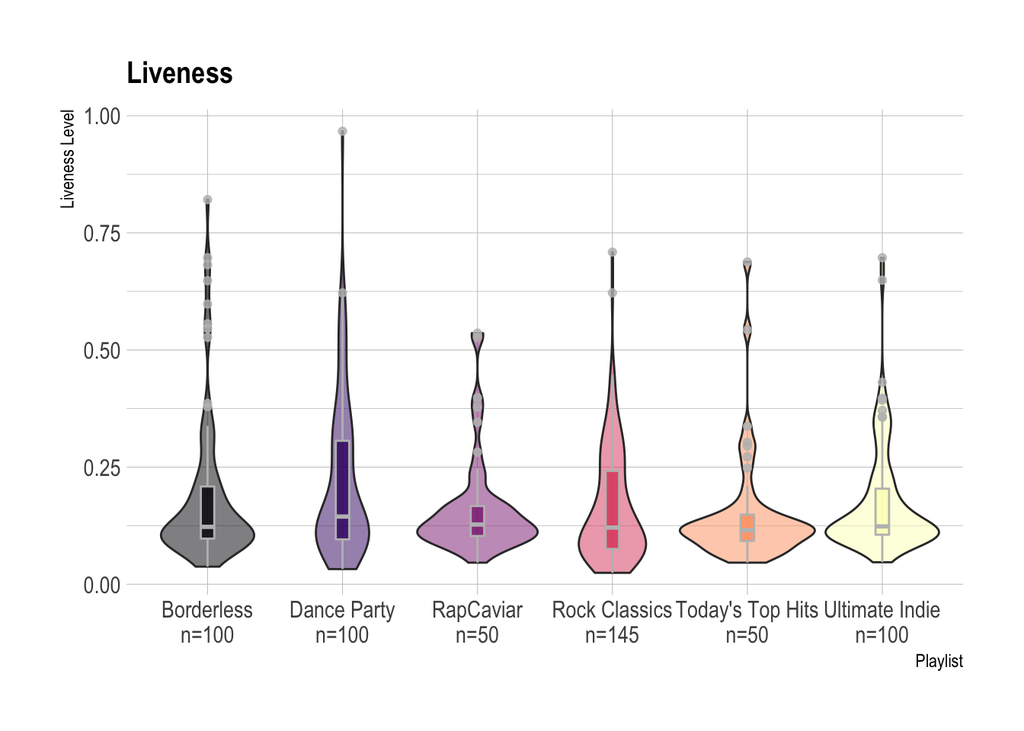

```r
# Plot
playlists_portfolio %>%
  left_join(sample_size_portfolio) %>%
  mutate(myaxis = paste0(playlist_name, "\n", "n=", num)) %>%
  ggplot( aes(x=myaxis, y=liveness, fill=playlist_name)) +
    geom_violin(width=1, alpha=0.5) +
    geom_boxplot(width=0.1, color="grey", alpha=0.8) +
    scale_fill_viridis(discrete=TRUE, guide=FALSE, option="A") +
    theme_ipsum() +
    theme(
      legend.position="none",
      plot.title = element_text(size=15)
    ) +
    ggtitle("Liveness") +
    xlab("Playlist") +
  ylab("Liveness Level")
```

The distribution for liveness is mostly similar to Indie but is more smeared out for higher values for Borderless.

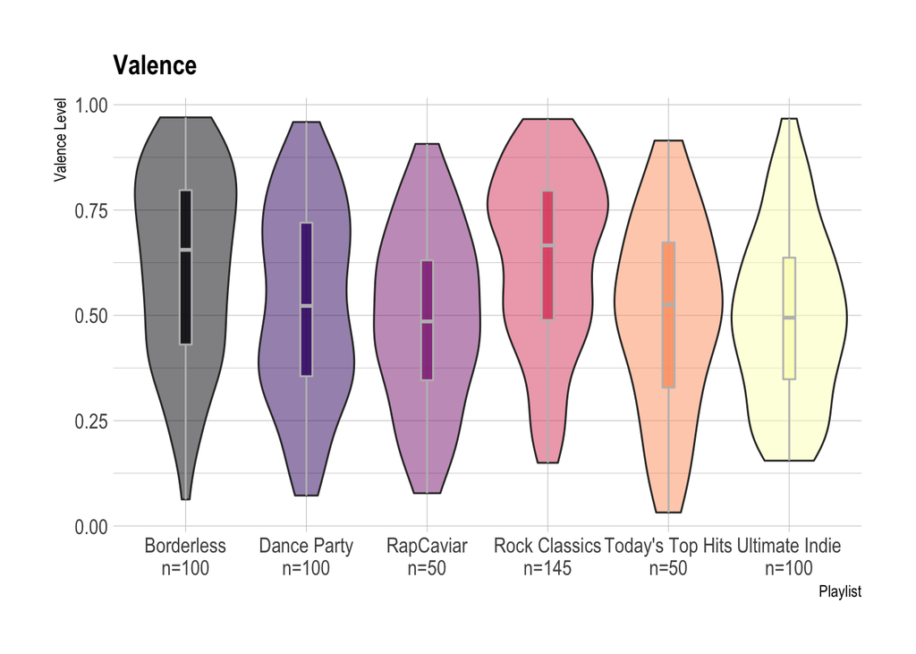

```r
# Plot
playlists_portfolio %>%
  left_join(sample_size_portfolio) %>%
  mutate(myaxis = paste0(playlist_name, "\n", "n=", num)) %>%
  ggplot( aes(x=myaxis, y=valence, fill=playlist_name)) +
    geom_violin(width=1, alpha=0.5) +
    geom_boxplot(width=0.1, color="grey", alpha=0.8) +
    scale_fill_viridis(discrete=TRUE, guide=FALSE, option="A") +
    theme_ipsum() +
    theme(
      legend.position="none",
      plot.title = element_text(size=15)
    ) +
    ggtitle("Valence") +
    xlab("Playlist") +
  ylab("Valence Level")
```

Valence would be most similar to Rock. However, there seem to be more lower valences in the Borderless playlist than in the Rock playlist.